# Introduction to rfExtra

# 1 Package description

In the `rfExtra` package, we added permutated-based group variable importance to the `randomForest()` function based on the `randomForest` package by Andy Liaw and Matthew Wiener. We modified the C code directly from the `randomForest` source package. Aside from the `importance` argument, the `rfExtra::randomForest()` function now accepts `groupImp` for group variable importance and `varGroups` as a factor vector indicating variable groups for predictor variables in the data set. For each group of variables, for each tree, the grouped variables are permutated individually first, and then the decrease in model performance (decrease in accuracy for classification; increase in percent mean squared error for regression) is recorded. We then compute the final importance after building all trees.

We also included the modified `combine()` function from the `randomForest` package. Unlike the `randomForest::combine()` function that turns standard deviations for the component `importanceSD`, the components `importanceSD` and `groupImportanceSD` returned from `rfExtra::combine()` will be standard errors. Specifically, in the original C code of the `randomForest()` function, it is the standard error that is calculated using the following code: `sqrt(((sum(delta * delta) / Ntree) - av*av) / Ntree);`, where `delta` indicates decrease in model performance. To combine smaller random forests generated with parallel computing, in the modified `rfExtra::combine()` function, we first revert the calculation for the standard error back to `sum(delta * delta)`, aggregate the results, and calculate the final standard error across all trees in the combined random forest.

# 2 Installation and setup

```r
# Install package from source
# install.packages('~/Downloads/rfExtra_0.0.0.9000.tar.gz',
# type='source', repos=NULL, force=TRUE)

# Load libraries
library(randomForest)
library(rfExtra)
library(parallel)
```

We will be using the “Parkinsons” data set from the UCI machine learning repository.

```r
# Load data set
data = read.table(file = "https://archive.ics.uci.edu/ml/machine-learning-databases/parkinsons/parkinsons.data",
    sep = ",", header = TRUE, check.names = FALSE)
data = subset(data, select = -name)
```

# 3 Classification examples

```r
# Set response variable
response = "status"

# Split data
predictor_vars = data[, colnames(data) != response]
predictor_vars = na.roughfix(predictor_vars)
response_var = data[, colnames(data) == response]

# Downsample to the smaller class size
response_var = as.factor(response_var)
min_size = min(table(response_var))
num_classes = length(table(response_var))
```

## 3.1 Group variable importance

The `rfExtra::randomForest()` function calculates permutation-based group importance with a specified length `p` factor vector `varGroups`, where `p` is the number of predictor variables.

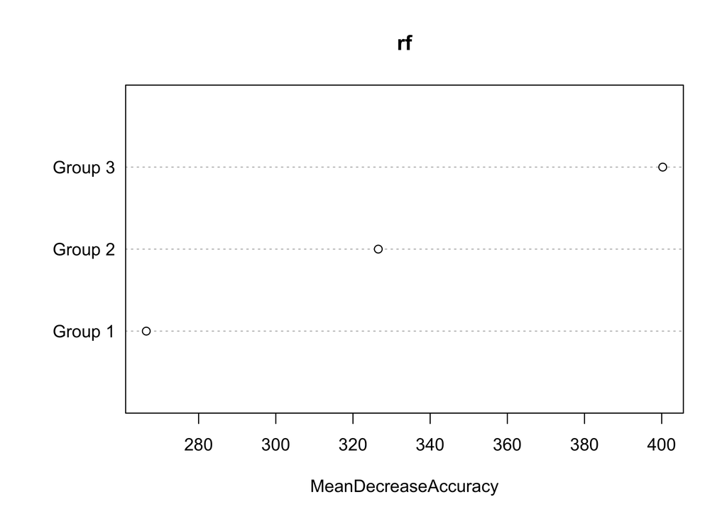

```r
# Set seed for reproducible results
set.seed(1)

# Train random forest
rf = rfExtra::randomForest(x = predictor_vars, y = response_var,
    importance = TRUE, groupImp = TRUE, ntree = 1e+05,
    sampsize = rep(min_size, num_classes), varGroups = factor(c(rep("Group 1",
        5), rep("Group 2", 11), rep("Group 3", 6))))

# Plot group variable importance
grpVarImpPlot(rf)
```

## 3.2 Building random forest in parallel

We can also build the random forest with parallel computing and use the `rfExtra::combine()` function to combine the results.

```r
# Set number of parallel streams and number of
# trees for each stream
num_jobs = 8
ntree_per_job = ceiling(1e+05/num_jobs)

# Set seed for parallel environment
set.seed(1, "L'Ecuyer-CMRG")

# Train random forest models in parallel
res = mclapply(1:num_jobs, function(num_jobs) rfExtra::randomForest(x = predictor_vars,
    y = response_var, ntree = ntree_per_job, importance = TRUE,
    groupImp = TRUE, sampsize = rep(min_size, num_classes),
    varGroups = factor(c(rep("Group 1", 5), rep("Group 2",
        11), rep("Group 3", 6)))))

# Combine results
par_rf = do.call(rfExtra::combine, res)
```

The confusion matrices and error rates of the random forest models trained using a single core and multiple cores are similar.

```r
rf$confusion
```

```
##    0   1 class.error
## 0 42   6   0.1250000
## 1 15 132   0.1020408
```

```r
par_rf$confusion
```

```
##    0   1 class.error
## 0 42   6   0.1250000
## 1 16 131   0.1088435
```

```r
rf$err.rate[length(rf$err.rate)]
```

```
## [1] 0.1020408
```

```r
par_rf$err.rate
```

```
## [1] 0.1128205
```

## 3.3 Comparing random forest models

Here we compare six random forest models built with different parameter settings:

1. We first build a conventional random forest `randomForest_rf` using the `randomForest` package and calculate the importance of all predictor variables.

```r
set.seed(1)
randomForest_rf = randomForest::randomForest(x = predictor_vars,
    y = response_var, importance = TRUE, ntree = 1e+05,
    sampsize = rep(min_size, num_classes))
```

2. The second random forest `rfExtra_grpImp` is built using the `rfExtra` package, and the group permutation variable importance is calculated where each group contains only one variable. The arguments `importance` and `groupImp` are set to `FALSE` and `TRUE` respectively.

```r
set.seed(1)

# Each group only has one variable
groups = factor(colnames(predictor_vars), levels = colnames(predictor_vars))

rfExtra_grpImp = rfExtra::randomForest(x = predictor_vars,
    y = response_var, importance = FALSE, groupImp = TRUE,
    ntree = 1e+05, sampsize = rep(min_size, num_classes),
    varGroups = groups)
```

3. The random forest `rfExtra_no_grpImp` is built using the `rfExtra` package, and we only calculate individual variable importance by setting arguments `importance` and `groupImp` to `TRUE` and `FALSE` respectively.

```r
set.seed(1)
rfExtra_no_grpImp = rfExtra::randomForest(x = predictor_vars,
    y = response_var, importance = TRUE, groupImp = FALSE,
    ntree = 1e+05, sampsize = rep(min_size, num_classes))
```

4. We can also build a random forest in parallel. Here we show an example using the `randomForest` package and combine the smaller random forests with `ntree_per_job` trees using the `randomForest::combine()` function that returns standard deviations. The final random forest is called `par_rf_randomForest_cbne`.

```r
# Set number of parallel streams and number of
# trees for each stream
num_jobs = 8
ntree_per_job = ceiling(1e+05/num_jobs)

set.seed(1, "L'Ecuyer-CMRG")
randomForest_res = mclapply(1:num_jobs, function(num_jobs) randomForest::randomForest(x = predictor_vars,
    y = response_var, ntree = ntree_per_job, importance = TRUE,
    sampsize = rep(min_size, num_classes)))

par_rf_randomForest_cbne = do.call(randomForest::combine,
    randomForest_res)
```

5. To compare the `combine()` functions from `randomForest` and `rfExtra` packages, we generate the combined random forest `par_rf_rfExtra_cbne` using the `rfExtra::combine()` function that returns standard errors.

```r
par_rf_rfExtra_cbne = do.call(rfExtra::combine, randomForest_res)
```

6. Finally, we build another random forest in parallel using the modified `rfExtra::randForest` function that calculates group variable importance. We then combine the results using the `rfExtra::combine()` function.

```r
set.seed(1, "L'Ecuyer-CMRG")
rfExtra_res = mclapply(1:num_jobs, function(num_jobs) rfExtra::randomForest(x = predictor_vars,
    y = response_var, ntree = ntree_per_job, importance = FALSE,
    groupImp = TRUE, sampsize = rep(min_size, num_classes),
    varGroups = groups))

par_rf_rfExtra_grpImp = do.call(rfExtra::combine, rfExtra_res)
```

Here we can plot variable importance results for different random forests using the `varImpPlot()` function from the `randomForest` package or the `grpVarImpPlot()` function from the `rfExtra` package.

```r
par(mfrow = c(2, 3), mar = c(2, 2, 2, 2))
varImpPlot(randomForest_rf, type = 1)
grpVarImpPlot(rfExtra_grpImp)
varImpPlot(rfExtra_no_grpImp, type = 1)
varImpPlot(par_rf_randomForest_cbne, type = 1)
varImpPlot(par_rf_rfExtra_cbne, type = 1)
grpVarImpPlot(par_rf_rfExtra_grpImp)
```

[figure not shown]

```r
# Compare importance measures of randomForest_rf,
# rfExtra_grpImp, and rfExtra_no_grpImp
identical(importance(randomForest_rf, type = 1), groupImportance(rfExtra_grpImp))
```

```
## [1] TRUE
```

```r
identical(importance(randomForest_rf, type = 1), importance(rfExtra_no_grpImp,
    type = 1))
```

```
## [1] TRUE
```

```r
# Compare importance measures of
# par_rf_rfExtra_cbne and par_rf_rfExtra_grpImp
identical(importance(par_rf_rfExtra_cbne, type = 1),
    groupImportance(par_rf_rfExtra_grpImp))
```

```
## [1] TRUE
```

The variable importance values in terms of ranks and magnitudes are the same for `randomForest_rf`, `rfExtra_grpImp`, and `rfExtra_no_grpImp`, which were built using the same seed number. However, note that the individual variable importance and group variable importance are calculated sequentially for each tree in the `rfExtra::randomForest()` function. Thus, setting both `importance` and `groupImp` to `TRUE` may slightly change importance ranks, though this may not be a big issue for general variable importance interpretation.

The importance measures for `par_rf_randomForest_cbne` and `par_rf_rfExtra_cbne` differ in magnitudes because the former used standard deviations to scale variable importance, whereas the latter used standard errors. The `par_rf_rfExtra_cbne` and `par_rf_rfExtra_grpImp` have the same variable importance results because they were built using the same random seeds in the parallel environment.

# 4 Regression examples

Similar to the classification examples, here we show examples of running `rfExtra::randomForest()` using a single core or multiple cores in parallel.

```r
# Set response variable
response = "PPE"

# Split data
predictor_vars = data[, colnames(data) != response]
predictor_vars = na.roughfix(predictor_vars)
response_var = data[, colnames(data) == response]
```

## 4.1 Group variable importance

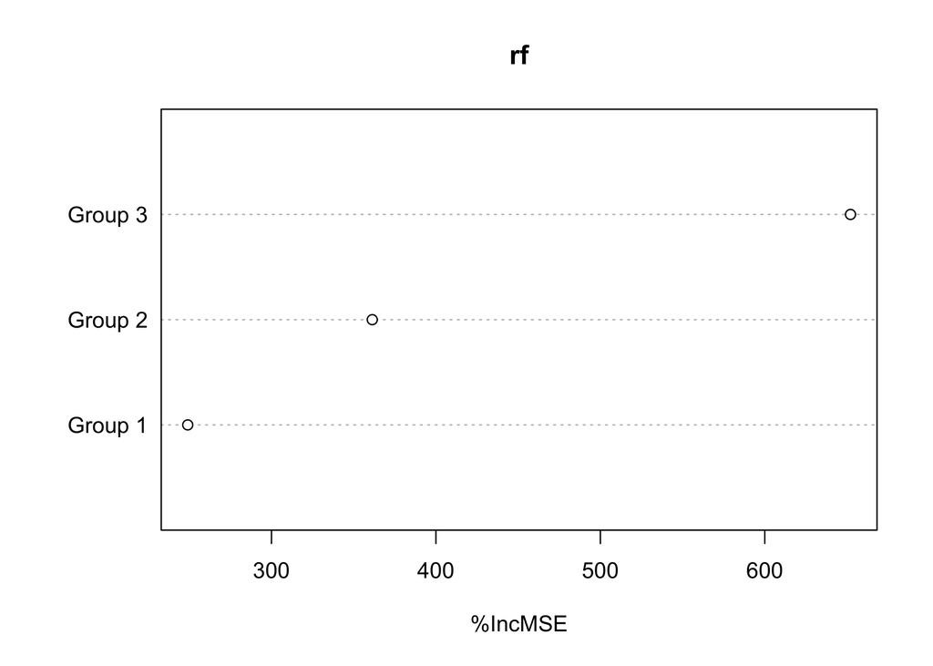

```r
# Set seed for reproducible results
set.seed(1)

# Train random forest
rf = rfExtra::randomForest(x = predictor_vars, y = response_var,
    importance = TRUE, groupImp = TRUE, ntree = 1e+05,
    varGroups = factor(c(rep("Group 1", 5), rep("Group 2",
        11), rep("Group 3", 6))))

# Plot group variable importance
grpVarImpPlot(rf)
```

## 4.2 Building random forest in parallel

```r
# Set number of parallel streams and number of
# trees for each stream
num_jobs = 8
ntree_per_job = ceiling(1e+05/num_jobs)

# Set seed for parallel environment
set.seed(1, "L'Ecuyer-CMRG")

# Train random forest models in parallel
res = mclapply(1:num_jobs, function(num_jobs) rfExtra::randomForest(x = predictor_vars,
    y = response_var, ntree = ntree_per_job, importance = TRUE,
    groupImp = TRUE, varGroups = factor(c(rep("Group 1",
        5), rep("Group 2", 11), rep("Group 3", 6)))))

# Combine results
par_rf = do.call(rfExtra::combine, res)
```

The mean squared errors and (pseudo) R-squared values are similar for the two models.

```r
rf$mse[length(rf$mse)]
```

```
## [1] 0.0006484234
```

```r
par_rf$mse
```

```
## [1] 0.0006483543
```

```r
rf$rsq[length(rf$rsq)]
```

```
## [1] 0.919748
```

```r
par_rf$rsq
```

```
## [1] 0.9197566
```

## 4.3 Comparing random forest models

We build random forests with the same parameter settings as the classification examples:

1. We first build a conventional random forest `randomForest_rf` using the `randomForest` package and calculate the importance of all predictor variables.

```r
set.seed(1)
randomForest_rf = randomForest::randomForest(x = predictor_vars,
    y = response_var, importance = TRUE, ntree = 1e+05)
```

2. The second random forest `rfExtra_grpImp` is built using the `rfExtra` package, and the group permutation variable importance is calculated where each group contains only one variable. The arguments `importance` and `groupImp` are set to `FALSE` and `TRUE` respectively.

```r
set.seed(1)

# Each group only has one variable
groups = factor(colnames(predictor_vars), levels = colnames(predictor_vars))

rfExtra_grpImp = rfExtra::randomForest(x = predictor_vars,
    y = response_var, importance = FALSE, groupImp = TRUE,
    ntree = 1e+05, varGroups = groups)
```

3. The random forest `rfExtra_no_grpImp` is built using the `rfExtra` package, and we only calculate individual variable importance by setting arguments `importance` and `groupImp` to `TRUE` and `FALSE` respectively.

```r
set.seed(1)
rfExtra_no_grpImp = rfExtra::randomForest(x = predictor_vars,
    y = response_var, importance = TRUE, groupImp = FALSE,
    ntree = 1e+05)
```

4. We can also build a random forest in parallel. Here we show an example using the `randomForest` package and combine the smaller random forests with `ntree_per_job` trees using the `randomForest::combine()` function that returns standard deviations. The final random forest is called `par_rf_randomForest_cbne`.

```r
# Set number of parallel streams and number of
# trees for each stream
num_jobs = 8
ntree_per_job = ceiling(1e+05/num_jobs)

set.seed(1, "L'Ecuyer-CMRG")
randomForest_res = mclapply(1:num_jobs, function(num_jobs) randomForest::randomForest(x = predictor_vars,
    y = response_var, ntree = ntree_per_job, importance = TRUE))

par_rf_randomForest_cbne = do.call(randomForest::combine,
    randomForest_res)
```

5. To compare the `combine()` functions from `randomForest` and `rfExtra` packages, we generate the combined random forest `par_rf_rfExtra_cbne` using the `rfExtra::combine()` function that returns standard errors.

```r
par_rf_rfExtra_cbne = do.call(rfExtra::combine, randomForest_res)
```

6. Finally, we build another random forest in parallel using the modified `rfExtra::randForest` function that calculates group variable importance. We then combine the results using the `rfExtra::combine()` function.

```r
set.seed(1, "L'Ecuyer-CMRG")
rfExtra_res = mclapply(1:num_jobs, function(num_jobs) rfExtra::randomForest(x = predictor_vars,
    y = response_var, ntree = ntree_per_job, importance = FALSE,
    groupImp = TRUE, varGroups = groups))

par_rf_rfExtra_grpImp = do.call(rfExtra::combine, rfExtra_res)
```

The variable importance plots are shown below. The comparison results are similar to those shown in the classification section.

```r
par(mfrow = c(2, 3), mar = c(2, 2, 2, 2))
varImpPlot(randomForest_rf, type = 1)
grpVarImpPlot(rfExtra_grpImp)
varImpPlot(rfExtra_no_grpImp, type = 1)
varImpPlot(par_rf_randomForest_cbne, type = 1)
varImpPlot(par_rf_rfExtra_cbne, type = 1)
grpVarImpPlot(par_rf_rfExtra_grpImp)
```

[figure not shown]

```r
# Compare importance measures of randomForest_rf,
# rfExtra_grpImp, and rfExtra_no_grpImp
identical(importance(randomForest_rf, type = 1), groupImportance(rfExtra_grpImp))
```

```
## [1] TRUE
```

```r
identical(importance(randomForest_rf, type = 1), importance(rfExtra_no_grpImp,
    type = 1))
```

```
## [1] TRUE
```

```r
# Compare importance measures of
# par_rf_rfExtra_cbne and par_rf_rfExtra_grpImp
identical(importance(par_rf_rfExtra_cbne, type = 1),
    groupImportance(par_rf_rfExtra_grpImp))
```

```
## [1] TRUE
```

# 5 References

Liaw, A. and Wiener, M. (2002), Classification and regression by randomForest, R news 2(3), 18–22, https://cran.r-project.org/web/packages/randomForest/randomForest.pdf.

Breiman, L. (2001), Random Forests, Machine Learning 45(1), 5-32.

Breiman, L (2002), “Manual On Setting Up, Using, And Understanding Random Forests V3.1”, https://www.stat.berkeley.edu/~breiman/Using_random_forests_V3.1.pdf.